# Spatial Analysis of Hospital Accessibility and District-Level Mortality in Philadelphia

BMIN503/EPID600 Final Project

Author

Yannan Bao

## 1 Overview

Healthcare access is a critical determinant of population health, yet spatial disparities can contribute to uneven health outcomes. This project investigates spatial disparities in healthcare access and their potential impact on mortality rates across Philadelphia districts. The main goal is to examine whether the spatial access to hospitals are associated with mortality rates, after adjusting for Social Determinants of Health (SDOH), using data from OpenDataPhilly and American Community Survey (ACS). Findings can inform targeted interventions and policy decisions aimed at improving population health.

## 2 Introduction

Unequal access to hospitals and healthcare services is a pressing challenge in many cities. Residents in districts with limited access may face longer travel distances, delayed treatment, and ultimately higher morbidity and mortality. These disparities can exacerbate existing health inequalities that are linked to socioeconomic status and other demographic factors. Previous research has shown that increasing spatial access to care is independently associated with lower in-hospital mortality(1). However, few studies have quantified how hospital accessibility affects all-cause mortality. This study thus examines whether hospital accessibility is associated with district-level mortality rates in Philadelphia, accounting for socioeconomic factors, using data from OpenDataPhilly and American Community Survey (ACS).

This is an interdisciplinary problem encompassing population health, Geographic Information Science (GIS), and health equity. Population health provides the framework for analyzing mortality patterns and methods to control confounding factors. GIS and spatial analytics enable the measurement of hospital accessibility and visualization of spatial inequities, while health justice examines resource distribution and equity issues. Insights from faulty were critical in guiding the methodological choices.

## 3 Methods

This study investigates the structural association between hospital accessibility and district-level mortality across 18 planning districts in Philadelphia (2013–2022). The core predictor, Hospital Accessibility (Ai), was quantified using the Two-Step Floating Catchment Area (2SFCA) method based on a 15-minute driving threshold on the actual road network, integrating both proximity and demand competition. The analytical strategy proceeds in three phases: First, descriptive statistics and exploratory plots were used to examine the spatial and temporal structure of the dataset. Second, structural analysis was conducted using univariate and SDOH-corrected multivariate Cross-Sectional OLS models. Third, Two-Way Fixed Effects (FE) model and the Pooled OLS model augmented with Clustered Standard Errors (SE) and Time Fixed Effects (TFE) were used for dynamic validation.

Data sources include OpenDataPhilly and American Community Survey (ACS). The outcome of interest is the age-adjusted all-cause mortality rate per 100,000 population at the planning-district level. Independent variable is hospital accessibility. Covariates include Poverty Rate, NH_Black population percentage, and Unemployment Rate.

### 3.1 1. Data Preparation

“Philadelphia Vital Statistics – Mortality (Deaths)”, “PA Hospitals” and “Planning Districts” were accessed from OpenDataPhilly. The outcome indicator, District-level mortality rates were measured by “final”, “All causes”, “age_adjusted_mortality_rate_per_100k”. Key Social Determinants of Health (SDOH) variables and population counts were collected at the Census Tract level from the ACS 5-year estimates. SDOH factors selected were Poverty Rate, NH_Black population percentage, and Unemployment Rate. The variable for ‘without insurance rate’ was excluded due to poor data quality (approximately 1/3 zero values). Hospital data excluded specialty facilities (behavioral health, VA, rehabilitation) that do not provide acute medical services. The study period is 2013–2022.

Census tracts with zero population were excluded to remove non-residential areas. The tract-level data was then transformed to match Planning Districts for further analysis.

```r
library(tidyverse)
library(tidymodels)
library(dotwhisker)
library(glmnet)
library(tidycensus)
library(sf)
library(tigris)
library(ggplot2)
library(dplyr)
library(osrm)
library(leaflet)
library(RColorBrewer)
library(plm)
library(lmtest)
library(sandwich)
library(car)
library(broom)
options(tigris_use_cache = TRUE)

mortality<-read.csv("Vital_Mortality_PD.csv")
hospital<-st_read("DOH_Hospitals202311/DOH_Hospitals202311.shp")
district<-st_read("Planning_Districts/Planning_Districts.shp")
#retrieve data from acs
years <- 2013:2022
acs_vars <- c(Total_Pop = "B01003_001",     # Total Population
              Poverty = "B17001_002",       #Income in the past 12 months below poverty level
              NH_Black = "B03002_004",      # Not Hispanic or Latino: Black or African American alone
              Unemployed = "B23025_005",    # Unemployed (Civilian Labor Force)
              Labor_Force = "B23025_003")   # Civilian Labor Force (Total)


acs <- map_df(years, function(x) {
  suppressMessages(
    suppressWarnings(
      get_acs(
        geography = "tract",
        variables = acs_vars,
        year = x,
        survey = "acs5",
        state = "PA",
        county = "Philadelphia",
        geometry = TRUE ))) |>
  mutate(year = x)
})

acs<- acs|>
  #Reshape the long-format table into a wide-format structure
  pivot_wider(id_cols = c(GEOID,year,geometry),
              names_from = variable,
              values_from = estimate,
              values_fn = mean)|> #for duplicate metrics, calculate the average
  filter(Total_Pop > 0)|>#remove tracts where no one lives
  #calculate percentage to replace absolute values
  mutate(Poverty = (Poverty / Total_Pop) * 100,
         NH_Black = (NH_Black / Total_Pop) * 100,
         Unemployed = (Unemployed / Labor_Force) * 100)|>
  select(-Labor_Force)#remove the unusable variable

mortality<-mortality|>
  filter(METRIC_NAME=="age_adjusted_mortality_rate_per_100k",
         LEADING_CAUSE_DEATH=="All causes",
         ESTIMATE_TYPE=="Final")|>
  select(YEAR,METRIC_VALUE,GEOGRAPHY_NAME)|>
  rename(year=YEAR,
         mortality=METRIC_VALUE,
         district=GEOGRAPHY_NAME)|>
  filter(year %in% 2013:2022)

hospital<-hospital|>
  filter(COUNTY=="Philadelphia")|>
  select(OBJECTID,FACILITY_N,STREET,ZIP_CODE,geometry)|>
  filter(OBJECTID %in% c(81,98,116,120,126,140,155,156,164,170,208,215)) #exclude behavioral health, VA, rehabilitation, and specialty hospitals that do not provide acute medical services

#unify crs
acs <- st_transform(acs, 4326)
hospital <- st_transform(hospital, 4326)
district<- st_transform(district, 4326)

#match tracts with planning districts
tracts_unique <- acs |>
  select(GEOID, geometry) |>
  distinct(GEOID, .keep_all = TRUE)
tracts_centroids <- st_centroid(tracts_unique)
tracts_with_district <- st_join(tracts_centroids, district, join = st_within)|>
  select(GEOID,DIST_NAME)|>
  st_drop_geometry()
acs<-left_join(acs, tracts_with_district,by="GEOID")|>
  rename(district=DIST_NAME)|>
  filter(!is.na(district))# the tract (GEOID:42101006500) can't match with any district, removing it won't greatly impact the results
```

### 3.2 2. Core Variable Construction: Hospital Accessibility

The primary explanatory variable, Hospital Accessibility ($A_i$), was calculated using the Two-Step Floating Catchment Area (2SFCA) method(2), a standard spatial metric supported by urban health literature to measure potential healthcare access. This method accounts for both geographical proximity and demand competition using the actual road network (OpenStreetMap). The accessibility was defined by a 15-minute driving time threshold ($d_0$). Calculation was performed at the tract centroid level to ensure higher accuracy before aggregating to the District level.

Step 1 (Supply-to-Demand Ratio, $\mathbf{R_j}$): For each hospital $j$ (Supply), the ratio ($R_j$) was calculated by dividing the hospital’s capacity (where $S_j = 1$ unit, simplifying all hospital services to a unit of accessibility) by the total population demand ($\sum P_k$) that falls within its 15-minute catchment area.

Step 2 (Accessibility Score, $\mathbf{A_i}$): The final accessibility score ($A_i$) for each tract centroid $i$ (Demand location) was calculated by summing the supply-to-demand ratios ($R_j$) of all hospitals accessible from $i$ within the same 15-minute travel time area.

The final score was scaled by 100,000 to represent accessibility per 100,000 people, aligning the unit with the mortality rate for interpretation. Then tract-level accessibility scores and SDOH variables were aggregated to the District level using tract population weights.

```r
##calculate driving time matrix (tract centroid---hospital)
all_ids <- tracts_centroids$GEOID
batch_size <- 50 # set batch size to prevent network timeouts
results <- list()#initialize a list for storing results

for(i in seq(1, length(all_ids), by=batch_size)){
  idx <- i:min(i+batch_size-1, length(all_ids))
  batch <- tracts_centroids[idx, ]
  # Call the OSRM service to calculate the travel time matrix (duration)
  dist_matrix <- osrmTable(src = batch, dst = hospital)
  tra_time <- as.data.frame(dist_matrix$durations)
  rownames(tra_time)<-batch$GEOID
  results[[length(results)+1]] <- tra_time
}
travel_time <- bind_rows(results)#convert the list into a big dataframe(driving time matrix)

## use 2SFCA to calculate hospital accessibility score
d0 <- 15# catchment
access<-list()
for (y in years){
  population<-acs|>
    filter(year==y)
  tra <- travel_time[population$GEOID, ]#ensure that index of population and travel_time are consistent

  #step 1:calculate Hospital Supply Ratio Rj for each hospital j
  pop_sum<-apply(tra,2,function(d){
    within<-which(d<=d0)#get the index of tracts that are withn t0 to each hospital j
    sum(population$Total_Pop[within])
  })
  R_j <-ifelse(pop_sum==0,0,1 / pop_sum )

  # calculate Ai for each tract i
  A_i <- apply(tra,1,function(d){
    within<-which(d<=d0)#get the index of hospitals that are withn t0 to each tract i
    sum(R_j[within],na.rm = TRUE)
  })

  tracts_access<-mutate(population,A_i=A_i,year=y)
  access[[length(access)+1]] <- tracts_access
}
final_access<-bind_rows(access)
acs<-mutate(acs,A_i_100k=final_access$A_i*100000)


#calculate district-level hospital accessibility and sdoh values using tract population weights
weighted_district <- acs|>
  st_drop_geometry()|>
  group_by(district,year)|>
  summarise(Ai= sum(Total_Pop * A_i_100k) / sum(Total_Pop),
            NH_Black=sum(Total_Pop * NH_Black) / sum(Total_Pop),
            Poverty=sum(Total_Pop * Poverty) / sum(Total_Pop),
            Unemployed=sum(Total_Pop * Unemployed,na.rm=TRUE) / sum(Total_Pop),#unemployed have na because labor force in some tract maybe 0
            .groups = "drop" )
mortality<-mortality|>
  left_join(weighted_district,by=c("district","year"))
```

Further analyses will be conducted in the Results section.

## 4 Results

### 4.1 1. Descriptive Statistics

Descriptive analysis was performed to calculate the mean, standard deviation, minimum, maximum, and between- and within-variation for all variables. This helped determine the data structure and quantify the structural gap versus annual fluctuation.

```r
##Descriptive analysis
avg_mortality<- mortality|>
  group_by(district)|>
  summarise(avg_mortality=mean(mortality),
            avg_Ai=mean(Ai),
            avg_NH_Black=mean(NH_Black),
            avg_Poverty=mean(Poverty),
            avg_Unemployed=mean(Unemployed))

vars <- c("mortality", "Ai","NH_Black", "Poverty","Unemployed")

stats <- function(full_data, avg_data, var_name) {
  # OVERALL statistics (180):The total variation across all observations
  overall_mean <- mean(full_data[[var_name]])
  overall_sd <- sd(full_data[[var_name]])
  overall_min <- min(full_data[[var_name]])
  overall_max <- max(full_data[[var_name]])

  #BETWEEN statistics (18 districts)：The variation of the group (district) means
  avg_var_name <- paste0("avg_", var_name)
  between_mean <- mean(avg_data[[avg_var_name]])
  between_sd <- sd(avg_data[[avg_var_name]])
  between_min <- min(avg_data[[avg_var_name]])
  between_max <- max(avg_data[[avg_var_name]])

  # WITHIN (10 years)
  # The 'Within' component captures the variability over time (or within each group), after removing the group-level mean. It is derived from the variance decomposition.
  # formula: Overall Variance = Between Variance + Within Variance
  # Within Std. Dev. = sqrt(Overall Std. Dev.^2 - Between Std. Dev.^2)
  within_sd_sq <- overall_sd^2 - between_sd^2
  within_sd <- ifelse(within_sd_sq < 0, 0,sqrt(within_sd_sq)) #in case of negative values

  #dataframe construction
  stats_results <- data.frame(
    variable = var_name,
    statistic = c("Overall", "Between", "Within"),
    #Within Mean is set to 0 because within variation is defined as (x_it - x̄_i),whose mean is zero for each group by construction.
    Mean = c(overall_mean, between_mean, 0.0),
    Sd = c(overall_sd, between_sd, within_sd),
    # Min and Max for the 'Within' component are less informative for de-meaned data and are thus set to NA to avoid misinterpretation.
    Min = c(overall_min, between_min, NA),
    Max = c(overall_max, between_max, NA))

  return(stats_results)
}

descriptive_list <- lapply(vars, function(var) {
  stats(mortality, avg_mortality, var)
})

final_descriptive <- bind_rows(descriptive_list)

final_descriptive
```

```
     variable statistic        Mean          Sd         Min         Max
1   mortality   Overall 873.5209512 164.4392462 255.8677996 1349.686535
2   mortality   Between 873.5209512 151.5635746 588.7543034 1110.922826
3   mortality    Within   0.0000000  63.7867428          NA          NA
4          Ai   Overall   0.7448982   0.1775591   0.4167306    1.171820
5          Ai   Between   0.7448982   0.1819262   0.4240221    1.146785
6          Ai    Within   0.0000000   0.0000000          NA          NA
7    NH_Black   Overall  38.2067776  28.6832791   3.4766227   92.883271
8    NH_Black   Between  38.2067776  29.3800067   6.1485632   90.183461
9    NH_Black    Within   0.0000000   0.0000000          NA          NA
10    Poverty   Overall  22.4547851  10.2841469   2.4451187   45.964925
11    Poverty   Between  22.4547851  10.3546268   4.4786525   42.371992
12    Poverty    Within   0.0000000   0.0000000          NA          NA
13 Unemployed   Overall  11.3199913   5.0030004   2.2944551   24.850860
14 Unemployed   Between  11.3199913   4.1838536   4.6217620   18.311061
15 Unemployed    Within   0.0000000   2.7432430          NA          NA
```

### 4.2 2. Exploratory plots

Plots are generated for exploratory analysis: 1) Static tract-level accessibility map (10-year average); 2) Static district-level mortality map (10-year average); 3) Annual mortality rate line charts. The goal was to observe inter-area differences and temporal trends and see if “higher accessibility equals lower mortality.”

```r
##Exploratory plots
#1)Static tract-level accessibility map (10-year average)
acs_avg<-acs|>
  st_drop_geometry()|>
  group_by(GEOID)|>
  summarise(Ai_avg = mean(A_i_100k, na.rm = TRUE))|>
  left_join(tracts_unique,by="GEOID")|>
  st_as_sf()

#get the boundary of philly to make the picture complete(fill the tracts with no living population)
philly_county_boundary <- suppressMessages(
        suppressWarnings(
          get_acs(
            geography = "county",
            variables = "B01001_001",
            state = "PA",
            county = "Philadelphia",
            geometry = TRUE)))|>
  st_transform(4326)

#create the breaks manually
quants <- seq(0, 1, by = 1/9)
breaks <- quantile(acs_avg$Ai_avg, probs = quants, na.rm = TRUE)
labels <- c()
for (i in 1:9) {
    labels[i] <- paste0(round(breaks[i], 4), " - ", round(breaks[i + 1], 4))}

pal_fun1 <- colorBin(
  palette = "YlOrRd",
  domain = acs_avg$Ai_avg,
  bins = breaks,
  pretty = FALSE)

# Pop-up message
pu_message1 <- paste0("GEOID: ", acs_avg$GEOID,"<br>Hospital Accessibility per 100k people:<br>", round(acs_avg$Ai_avg, 4))

#plotting
map_Ai <- leaflet(acs_avg) |>
  #add border as background color filling
  addPolygons(stroke = FALSE,
              data = philly_county_boundary,
              fillColor = "lightgray",
              fillOpacity = 0.6) |>
  #add tract-level hospital accessibilty
  addPolygons(stroke = FALSE,                        # remove polygon borders
              fillColor = ~ pal_fun1(Ai_avg),
              fillOpacity = 0.8, smoothFactor = 0.5,
              popup = pu_message1) |>
  #add district border lines
  addPolylines(data = district,
               weight = 2,
               color = "black")|>
  addProviderTiles(providers$CartoDB.Positron) |>   # add third party provider tile
  addLegend("bottomright",
            pal = pal_fun1,
            values = ~ Ai_avg,
            labels = labels,
            title = 'Hospital Accessibility<br>per 100k people',
            opacity = 1) |>
  addLegend("bottomright",
          colors = "lightgray",
          labels = "Non-Residential Area",
          opacity = 1,
          title = "")|>
  addScaleBar()

map_Ai
```

[interactive chart not shown]

```r
#2) Static district-level mortality map (10-year average)
avg_mortality<-district|>
  rename(district=DIST_NAME)|>
  select(district)|>
  right_join(avg_mortality,by="district")

pal_fun2 <- colorNumeric("BuPu", NULL)
pu_message2 <- paste0(avg_mortality$district,"<br>Mortality per 100k people:<br>", round(avg_mortality$avg_mortality, 4))

map_mortality <- leaflet(avg_mortality) |>
  addPolygons(stroke = FALSE,
              fillColor = ~ pal_fun2(avg_mortality),
              fillOpacity = 0.8, smoothFactor = 0.5,
              popup = pu_message2) |>
  addProviderTiles(providers$CartoDB.Positron) |>
  addLegend("bottomright",
            pal = pal_fun2,
            values = ~ avg_mortality,
            title = 'Mortality Rate per 100k people',
            opacity = 1) |>
  addScaleBar()

map_mortality
```

[interactive chart not shown]

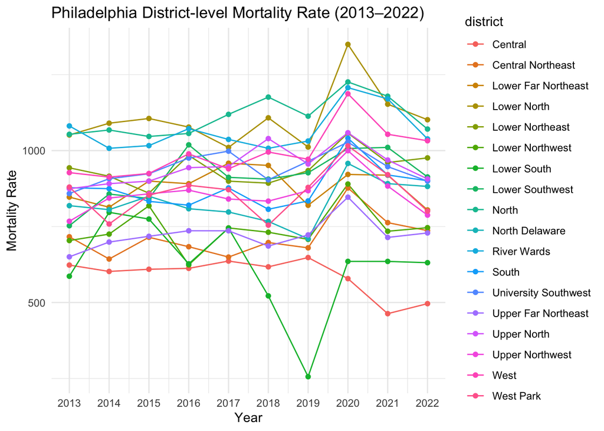

```r
#3) Annual mortality rate line charts.
line_mortality <- mortality |>
  ggplot(aes(x = year, y = mortality, color = district)) +
  geom_line() +
  geom_point() +
  scale_x_continuous(breaks = 2013:2022) +
  theme_minimal() +
  labs(
    title = "Philadelphia District-level Mortality Rate (2013–2022)",
    x = "Year",
    y = "Mortality Rate"
  )

line_mortality
```

### 4.3 3. Preliminary Structural Analysis (Cross-Sectional OLS)

Use ten-year averages (N=18 districts) to do structural Analysis:1) univariate linear regression; 2) sdoh-adjusted multivariate OLS

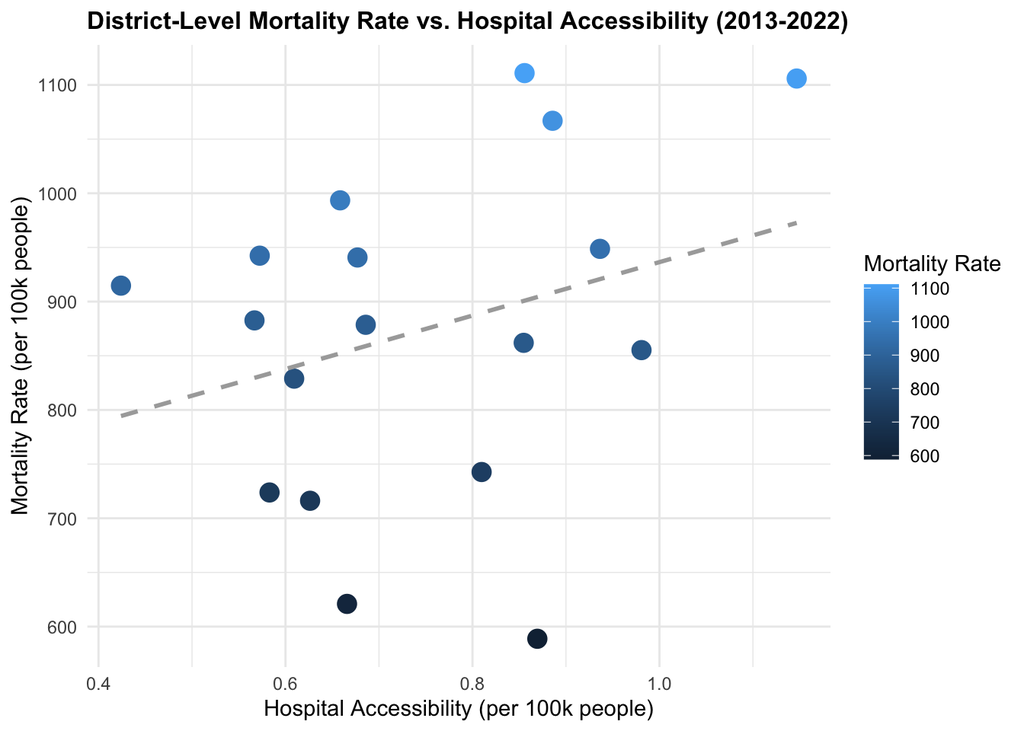

```r
#1）univariate linear regression (scatter plot)
point_mor_ai<-ggplot(avg_mortality, aes(x = avg_Ai, y = avg_mortality)) +
  geom_point(aes(color = avg_mortality), size = 4) +
  geom_smooth(method = "lm", se = FALSE, color = "darkgrey", linetype = "dashed") +
  labs(title = "District-Level Mortality Rate vs. Hospital Accessibility (2013-2022)",
       x = "Hospital Accessibility (per 100k people)",
       y = "Mortality Rate (per 100k people)",
       color = "Mortality Rate" ) +
  theme_minimal() +
  theme(plot.title = element_text(face = "bold", size = 12),
          strip.text = element_text(face = "bold"),
          legend.position = "right")

point_mor_ai
```

```r
#2） sdoh-adjusted multivariate OLS
avg_model<-lm(avg_mortality ~ avg_Ai+ avg_NH_Black + avg_Poverty + avg_Unemployed,
              data=avg_mortality)

vif(avg_model)
```

```
        avg_Ai   avg_NH_Black    avg_Poverty avg_Unemployed
      1.160350       1.749413       5.663573       5.284703
```

```r
summary(avg_model)
```

```
Call:
lm(formula = avg_mortality ~ avg_Ai + avg_NH_Black + avg_Poverty +
    avg_Unemployed, data = avg_mortality)

Residuals:
     Min       1Q   Median       3Q      Max
-111.431  -36.476   -7.347   21.231  170.625

Coefficients:
               Estimate Std. Error t value Pr(>|t|)
(Intercept)    479.9156    91.0231   5.272 0.000151 ***
avg_Ai          68.4858   107.3172   0.638 0.534449
avg_NH_Black    -0.7399     0.8160  -0.907 0.381019
avg_Poverty      6.5028     4.1656   1.561 0.142517
avg_Unemployed  19.8623     9.9587   1.994 0.067506 .
---
Signif. codes:  0 '***' 0.001 '**' 0.01 '*' 0.05 '.' 0.1 ' ' 1

Residual standard error: 74.73 on 13 degrees of freedom
Multiple R-squared:  0.8141,    Adjusted R-squared:  0.7569
F-statistic: 14.23 on 4 and 13 DF,  p-value: 0.000112
```

1) Univariate linear regression: A scatter plot and univariate OLS model were used, which revealed a counter-intuitive positive correlation, suggesting that higher access coincided with higher mortality.

2) sdoh-adjusted multivariate OLS : To better estimate the impact of accessibility on mortality, a multivariate cross-sectional OLS model was constructed, including SDOH variables to correct for this structural bias. After correction, Accessibility (p=0.534), NH_Black(p=0.381) and Poverty(p=0.143) were insignificant, and the Unemployment Rate (p=0.067) was marginally significant. VIF analysis confirmed multicollinearity between Poverty (5.66) and Unemployment (5.28). This multicollinearity suggested the low statistical power of the cross-sectional OLS due to the small sample size (N=18), necessitating a move to the panel structure.

### 4.4 4. Dynamic Validation (Panel Data): Pooled OLS + Clustered SE+TFE model

The final dynamic analysis utilized the full panel structure (18 districts * 10 years = 180 observations) to overcome statistical limitations. Model: 1)Two-Way Fixed Effects (FE) model; 2) Pooled OLS+Clustered SE+TFE model

```r
#1）Two-Way Fixed Effects (FE) model
# construct panel data
pdata <- pdata.frame(mortality, index = c("district", "year"))

fixed_model <- plm(
  mortality ~ Ai+ NH_Black + Poverty + Unemployed ,
  data = pdata,
  model = "within",
  effect="twoways"
)

summary(fixed_model)
```

```
Twoways effects Within Model

Call:
plm(formula = mortality ~ Ai + NH_Black + Poverty + Unemployed,
    data = pdata, effect = "twoways", model = "within")

Balanced Panel: n = 18, T = 10, N = 180

Residuals:
     Min.   1st Qu.    Median   3rd Qu.      Max.
-323.5683  -31.1329    1.1319   27.1559  203.8392

Coefficients:
            Estimate Std. Error t-value Pr(>|t|)
Ai          840.0571  1098.5267  0.7647   0.4457
NH_Black      2.8059     3.3058  0.8488   0.3974
Poverty      -4.0993     3.5739 -1.1470   0.2532
Unemployed   -5.1641     3.4907 -1.4794   0.1412

Total Sum of Squares:    577410
Residual Sum of Squares: 559020
R-Squared:      0.031855
Adj. R-Squared: -0.16307
F-statistic: 1.22564 on 4 and 149 DF, p-value: 0.30242
```

```r
#2) Pooled OLS+Clustered SE+TFE model (final model)
pooled_model <- plm(
    mortality ~ Ai + NH_Black+ Poverty + Unemployed + factor(year),
    data = pdata,
    model = "pooling"
)

# Calculate Cluster-Robust Standard Errors
robust_se_clustered <- vcovHC(
    pooled_model,
    type = "HC1",
    #Cluster by group (District) to correct for within-district serial correlation
    cluster = "group"
)
# Use coeftest to apply the new cluster-robust standard errors to the model coefficients
summary_robust <- coeftest(pooled_model, vcov = robust_se_clustered)
tidy(summary_robust)
```

```
# A tibble: 14 × 5
   term             estimate std.error statistic  p.value
   <chr>               <dbl>     <dbl>     <dbl>    <dbl>
 1 (Intercept)       431.       69.8       6.18  4.90e- 9
 2 Ai                 55.9      70.4       0.795 4.28e- 1
 3 NH_Black           -0.506     0.561    -0.901 3.69e- 1
 4 Poverty             8.91      2.12      4.20  4.35e- 5
 5 Unemployed         11.1       4.19      2.65  8.84e- 3
 6 factor(year)2014   11.9      18.4       0.648 5.18e- 1
 7 factor(year)2015   44.3      18.6       2.38  1.82e- 2
 8 factor(year)2016   72.1      20.7       3.49  6.22e- 4
 9 factor(year)2017   88.6      24.0       3.69  3.06e- 4
10 factor(year)2018   88.0      29.6       2.97  3.40e- 3
11 factor(year)2019   85.0      35.8       2.38  1.86e- 2
12 factor(year)2020  256.       24.6      10.4   7.13e-20
13 factor(year)2021  169.       24.2       7.01  5.57e-11
14 factor(year)2022  126.       20.7       6.11  6.70e- 9
```

1) Fixed Effects Challenge (Failure): An initial Two-Way Fixed Effects (FE) model was attempted to control for time-invariant area differences and time-specific shocks (e.g., COVID-19 pandemic led to 2020 mortality spike). However, the FE model exhibited model failure with negative Adjusted R^2 (Adjusted R^2=-0.163), which might be caused by the little change of independent variables over the ten-year period, leading to low statistical power.

2) Pooled OLS+Clustered SE+TFE model: So i switched to the Pooled OLS model to leverage high Between-Variation and increase statistical power. To ensure the robustness of the OLS coefficients, the model was augmented with two crucial corrections: Clustered Standard Errors and Time Fixed Effects (TFE). Clustered Standard Errors (by district) were applied to eliminate the bias caused by within-group serial correlation, recognizing that observations within the same district across different years are not independent. Time Fixed Effects (TFE) were included to control for unobserved, time-specific shocks common to all districts (e.g., the Opioid Crisis and the COVID-19 pandemic).

The final model (Pooled OLS+Clustered SE+TFE model) showed that Accessibility(p=0.428) and NH_Black(p=0.369) remain insignificant, while Poverty(p<0.001) and Unemployment(p<0.01)are highly significant. The model successfully isolated the dynamic contribution of the Unemployment rate, distinguishing it from the static contribution of Poverty. Quantitatively, a 1% increase in Poverty is associated with 8.9 additional deaths per 100k (p < 0.001); a 1% increase in Unemployment is associated with 11.1 additional deaths per 100k (p < 0.01).

## 5 Conclusion

The models prove that Hospital accessibility is not an independent statistical predictor of mortality rates. Instead, poverty and unemployment are the true contributors. A 1% increase in Poverty is associated with 8.9 additional deaths per 100k (p < 0.001); a 1% increase in Unemployment is associated with 11.1 additional deaths per 100k (p < 0.01). Consequently, reducing mortality inequality requires a shift in intervention focus from physical hospital construction to economic intervention (such as job creation and poverty alleviation). Resources must be prioritized based on unemployment and poverty rates, the real drivers of mortality. For future research, expanding the sample size and integrating real-time hospital capacity data are recommended to enhance accuracy.

## 6 Acknowledgement

Sincere thanks to Professor Anurag Verma, Professor Brielin C Brown, Chloe F Paris (TA) for their invaluable guidance, expertise, and constructive feedback throughout this research. Special thanks to Max Salvatore (TA) and all classmates for their kindness and help.

## 7 Reference

(1) McCrum ML, Allen CM, Han J, Iantorno SE, Presson AP, Wan N. Greater spatial access to care is associated with lower mortality for emergency general surgery. J Trauma Acute Care Surg. 2023 Feb 1;94(2):264-272. doi: 10.1097/TA.0000000000003837. Epub 2022 Nov 15. PMID: 36694335; PMCID: PMC10069479.

(2) Luo, W., & Wang, F. (2003). Measures of spatial accessibility to health care in a GIS environment: Synthesis and a case study in the Chicago region. *Environment and Planning B: Planning and Design, 30*(6), 865–884. https://doi.org/10.1068/b29120